# Project 1: K Nearest Neighbors

## Data set 2: SAheart

We will be performing the above calulations and plotting function for all of the data sets given to us. ### Code

```r
  #

  #--------------------NN1ToKmaxPredict------------------------------------
  SAheart<-Prep_SAheart()

  print("KNN_SAheart_Tests: Question:1")
```

```
#> [1] "KNN_SAheart_Tests: Question:1"
```

```r
  Fold.vec = Random_Folds(SAheart$n_Elements,4)
  Fold.n   = 4
  KNNLearnCV.List = KNNLearnCV(SAheart$TrainingData, SAheart$TrainingLabels, 30, Fold.vec, Fold.n)
```

```
#> [1] FALSE
```

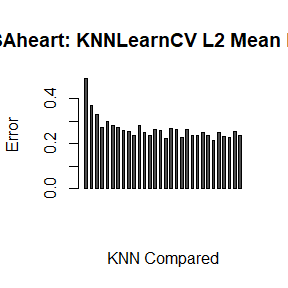

```r
  barplot(KNNLearnCV.List$TestMeanError.Means,main = "SAheart: KNNLearnCV L2 Mean Error",
          xlab = "KNN Compared",ylab = "Error",beside = TRUE)
```

```r
  #------------------------------------------------------------------------
```

### Matrix of loss values

```r
#-------------------UntrainedCV-------------------------------------
  SAheart_LossMatrix <-rbind(as.double(KNNLearnCV.List$TestMeanError.mat[,1]),
                             as.double(KNNLearnCV.List$TestMeanError.mat[,KNNLearnCV.List$selected.KNN]))
print(as.double(KNNLearnCV.List$TestMeanError.mat[,1]))
```

```
#> [1] 0.4234234 0.5221239 0.5315315 0.4803150
```

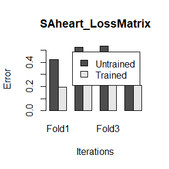

```r
#print(as.double(KNNLearnCV.List$train.loss.mat[,as.integer(KNNLearnCV.List$selected.KNN)]))

  colnames(SAheart_LossMatrix)<-c("Fold1","Fold2","Fold3","Fold4")
  rownames(SAheart_LossMatrix)<-c("Untrained","Trained")
  barplot(SAheart_LossMatrix, xlab = "Iterations", ylab = "Error",main = "SAheart_LossMatrix",legend = (rownames(SAheart_LossMatrix)),beside = TRUE)
```

### Train/validation loss plot

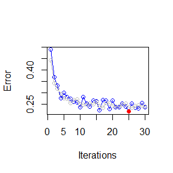

```r
  plot(colMeans(as.matrix(KNNLearnCV.List$TestMeanError.mat)),type="o", col = "blue", xlab = "Iterations", ylab = "Error",main = "")
  lines(colMeans(as.matrix(KNNLearnCV.List$TrainMeanError.mat)),type="o", col = "gray")

dot.x <- KNNLearnCV.List$selected.KNN
dot.y <- KNNLearnCV.List$TestMeanError.Means[dot.x]

matpoints(x = dot.x,
          y = dot.y,
          col = 2,
          pch = 19)
```

```r
 # legend(25,30,c("decay","growth"),col=c("blue","red"),pch=c(15,19), y.intersp=1800)
```

## Data set 3: Zip.train

### Code and itteration loss

```r
  Ziptrain<-Prep_Ziptrain()
  print("KNN_Ziptrain_Tests: ")
```

```
#> [1] "KNN_Ziptrain_Tests: "
```

```r
  Fold.vec = Random_Folds(Ziptrain$n_Elements,4)
  Fold.n   = 4


  #--------------------KNNLearnCV------------------------------------
  KNNLearnCV.List = KNNLearnCV(Ziptrain$TrainingData, Ziptrain$TrainingLabels, 30, Fold.vec, Fold.n)
```

```
#> [1] FALSE
```

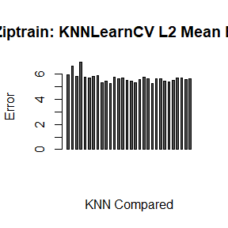

```r
  barplot(KNNLearnCV.List$TestMeanError.Means,main = "Ziptrain: KNNLearnCV L2 Mean Error",xlab = "KNN Compared",ylab = "Error",beside = TRUE)
```

```r
  #------------------------------------------------------------------------
```

### Matrix of loss values

```r
#-------------------UntrainedCV-------------------------------------
  ZipTrain_LossMatrix <-rbind(as.double(KNNLearnCV.List$TestMeanError.mat[,1]),as.double(KNNLearnCV.List$TestMeanError.mat[,KNNLearnCV.List$selected.KNN]))
print(as.double(KNNLearnCV.List$TestMeanError.mat[,1]))
```

```
#> [1] 5.385882 7.362096 5.492902 5.697842
```

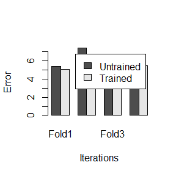

```r
#print(as.double(KNNLearnCV.List$train.loss.mat[,as.integer(KNNLearnCV.List$selected.KNN)]))

  colnames(ZipTrain_LossMatrix)<-c("Fold1","Fold2","Fold3","Fold4")
  rownames(ZipTrain_LossMatrix)<-c("Untrained","Trained")
  barplot(ZipTrain_LossMatrix, xlab = "Iterations", ylab = "Error",main = "",legend = (rownames(ZipTrain_LossMatrix)),beside = TRUE)
```

### Train/validation loss plot

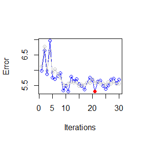

```r
  plot(colMeans(as.matrix(KNNLearnCV.List$TestMeanError.mat)),type="o", col = "blue", xlab = "Iterations", ylab = "Error",main = "")
  lines(colMeans(as.matrix(KNNLearnCV.List$TrainMeanError.mat)),type="o", col = "gray")
  #legend(25,30,c("decay","growth"),col=c("blue","red"),pch=c(15,19), y.intersp=1800)
  dot.x <- KNNLearnCV.List$selected.KNN
  dot.y <- KNNLearnCV.List$TestMeanError.Means[dot.x]

  matpoints(x = dot.x,
            y = dot.y,
            col = 2,
            pch = 19)
```

## Data set 4: prostate

### Code

```r
  #--------------------NN1ToKmaxPredict------------------------------------
  Prostate<-Prep_Prostate()
  print("NN1ToKmax_Prostate_Tests: ")
```

```
#> [1] "NN1ToKmax_Prostate_Tests: "
```

```r
  Fold.vec = Random_Folds(Prostate$n_Elements,4)
  Fold.n   = 4
  KNNLearnCV.List = KNNLearnCV(Prostate$TrainingData, Prostate$TrainingLabels, 30, Fold.vec, Fold.n)
```

```
#> [1] FALSE
```

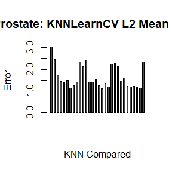

```r
  barplot(KNNLearnCV.List$TestMeanError.Means,main = "Prostate: KNNLearnCV L2 Mean Error",xlab = "KNN Compared",ylab = "Error",beside = TRUE)
```

```r
  #------------------------------------------------------------------------
```

### Matrix of loss values

```r
#-------------------UntrainedCV-------------------------------------
  Prostate_LossMatrix <-rbind(as.double(KNNLearnCV.List$TestMeanError.mat[,1]),as.double(KNNLearnCV.List$TestMeanError.mat[,KNNLearnCV.List$selected.KNN]))
print(Prostate_LossMatrix)
```

```
#>          [,1]      [,2]     [,3]     [,4]
#> [1,] 1.445711 5.8191594 2.681262 2.145059
#> [2,] 1.098170 0.4360465 1.845032 1.028216
```

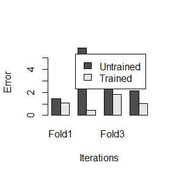

```r
#print(as.double(KNNLearnCV.List$train.loss.mat[,as.integer(KNNLearnCV.List$selected.KNN)]))

  colnames(Prostate_LossMatrix)<-c("Fold1","Fold2","Fold3","Fold4")
  rownames(Prostate_LossMatrix)<-c("Untrained","Trained")
  barplot(Prostate_LossMatrix, xlab = "Iterations", ylab = "Error",main = "",legend = (rownames(Prostate_LossMatrix)),beside = TRUE)
```

### Train/validation loss plot

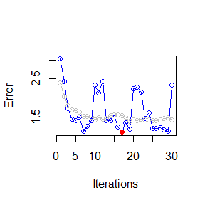

```r
  plot(colMeans(as.matrix(KNNLearnCV.List$TestMeanError.mat)),type="o", col = "blue", xlab = "Iterations", ylab = "Error",main = "")
  lines(colMeans(as.matrix(KNNLearnCV.List$TrainMeanError.mat)),type="o", col = "gray")
  #legend(25,30,c("decay","growth"),col=c("blue","red"),pch=c(15,19), y.intersp=1800)

  dot.x <- KNNLearnCV.List$selected.KNN
  dot.y <- KNNLearnCV.List$TestMeanError.Means[dot.x]

  matpoints(x = dot.x,
            y = dot.y,
            col = 2,
            pch = 19)
```

## Data set 5: ozone

### Code

```r
  #

  #--------------------NN1ToKmaxPredict------------------------------------
  Ozone<-Prep_Ozone()
  print("NN1ToKmax_Ozone_Tests: ")
```

```
#> [1] "NN1ToKmax_Ozone_Tests: "
```

```r
  Fold.vec = Random_Folds(Ozone$n_Elements,4)
  Fold.n   = 4
  KNNLearnCV.List = KNNLearnCV(Ozone$TrainingData, Ozone$TrainingLabels, 30, Fold.vec, Fold.n)
```

```
#> [1] FALSE
```

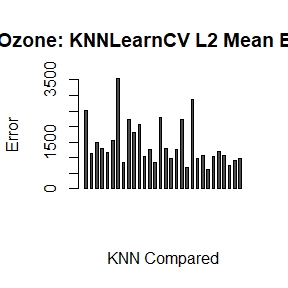

```r
  barplot(KNNLearnCV.List$TestMeanError.Means,main = "Ozone: KNNLearnCV L2 Mean Error",xlab = "KNN Compared",ylab = "Error",beside = TRUE)
```

```r
  #------------------------------------------------------------------------
```

### Matrix of loss values

```r
#-------------------UntrainedCV-------------------------------------
  Ozone_LossMatrix <-rbind(as.double(KNNLearnCV.List$TestMeanError.mat[,1]),as.double(KNNLearnCV.List$TestMeanError.mat[,KNNLearnCV.List$selected.KNN]))
print(as.double(KNNLearnCV.List$TestMeanError.mat[,1]))
```

```
#> [1] 1148.467 3180.886 4157.500 1639.636
```

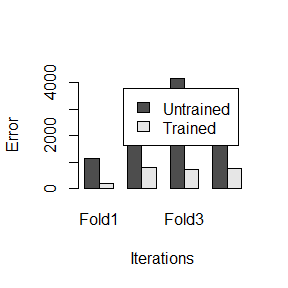

```r
#print(as.double(KNNLearnCV.List$train.loss.mat[,as.integer(KNNLearnCV.List$selected.KNN)]))

  colnames(Ozone_LossMatrix)<-c("Fold1","Fold2","Fold3","Fold4")
  rownames(Ozone_LossMatrix)<-c("Untrained","Trained")
  barplot(Ozone_LossMatrix, xlab = "Iterations", ylab = "Error",main = "",legend = (rownames(Ozone_LossMatrix)),beside = TRUE)
```

### Train/validation loss plot

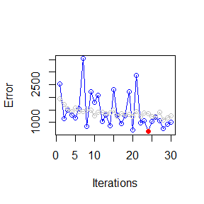

```r
  plot(colMeans(as.matrix(KNNLearnCV.List$TestMeanError.mat)),type="o", col = "blue", xlab = "Iterations", ylab = "Error",main = "")
  lines(colMeans(as.matrix(KNNLearnCV.List$TrainMeanError.mat)),type="o", col = "gray")
  #legend(25,30,c("decay","growth"),col=c("blue","red"),pch=c(15,19), y.intersp=1800)

  dot.x <- KNNLearnCV.List$selected.KNN
  dot.y <- KNNLearnCV.List$TestMeanError.Means[dot.x]

  matpoints(x = dot.x,
            y = dot.y,
            col = 2,
            pch = 19)
```

### Conclusion

What we can conclude from these experiments is that our medel selects the optimal value for the nearest neighbor as evidenced by the graphs of the mean validation loss when running the LearnCV function for each set. We had a very hard time with the first submission and we have fixed many of the issues including adding proper testthat functions for all the function dimensions.Our report compiles properly now and creates an html page as is is supposed to.